# Risk Factor Analysis

## Outcome Variable

**Outcome Variable:** wasted

## Predictor Variables

**Intervention Variable:** feducyrs

**Adjustment Set:**

- arm
- W_mage
- meducyrs
- W_mhtcm
- W_gagebrth
- W_birthwt
- W_birthlen
- single
- delta_W_mage
- delta_meducyrs
- delta_W_mhtcm
- delta_W_gagebrth
- delta_W_birthwt
- delta_W_birthlen
- delta_single

## Stratifying Variables

The analysis was stratified on these variable(s):

- agecat
- studyid
- country

## Data Summary

| agecat | studyid | country | feducyrs | wasted | n_cell | n |
| --- | --- | --- | --- | --- | --- | --- |
| Birth | ki0047075b-MAL-ED | BANGLADESH | High | 0 | 44 | 134 |
| Birth | ki0047075b-MAL-ED | BANGLADESH | High | 1 | 5 | 134 |
| Birth | ki0047075b-MAL-ED | BANGLADESH | Low | 0 | 26 | 134 |
| Birth | ki0047075b-MAL-ED | BANGLADESH | Low | 1 | 9 | 134 |
| Birth | ki0047075b-MAL-ED | BANGLADESH | Medium | 0 | 43 | 134 |
| Birth | ki0047075b-MAL-ED | BANGLADESH | Medium | 1 | 7 | 134 |
| Birth | ki0047075b-MAL-ED | INDIA | High | 0 | 34 | 121 |
| Birth | ki0047075b-MAL-ED | INDIA | High | 1 | 4 | 121 |
| Birth | ki0047075b-MAL-ED | INDIA | Low | 0 | 42 | 121 |
| Birth | ki0047075b-MAL-ED | INDIA | Low | 1 | 6 | 121 |
| Birth | ki0047075b-MAL-ED | INDIA | Medium | 0 | 29 | 121 |
| Birth | ki0047075b-MAL-ED | INDIA | Medium | 1 | 6 | 121 |
| Birth | ki0047075b-MAL-ED | NEPAL | High | 0 | 24 | 64 |
| Birth | ki0047075b-MAL-ED | NEPAL | High | 1 | 3 | 64 |
| Birth | ki0047075b-MAL-ED | NEPAL | Low | 0 | 17 | 64 |
| Birth | ki0047075b-MAL-ED | NEPAL | Low | 1 | 1 | 64 |
| Birth | ki0047075b-MAL-ED | NEPAL | Medium | 0 | 19 | 64 |
| Birth | ki0047075b-MAL-ED | NEPAL | Medium | 1 | 0 | 64 |
| Birth | ki0047075b-MAL-ED | PERU | High | 0 | 111 | 230 |
| Birth | ki0047075b-MAL-ED | PERU | High | 1 | 1 | 230 |
| Birth | ki0047075b-MAL-ED | PERU | Low | 0 | 62 | 230 |
| Birth | ki0047075b-MAL-ED | PERU | Low | 1 | 1 | 230 |
| Birth | ki0047075b-MAL-ED | PERU | Medium | 0 | 53 | 230 |
| Birth | ki0047075b-MAL-ED | PERU | Medium | 1 | 2 | 230 |
| Birth | ki0047075b-MAL-ED | SOUTH AFRICA | High | 0 | 34 | 91 |
| Birth | ki0047075b-MAL-ED | SOUTH AFRICA | High | 1 | 1 | 91 |
| Birth | ki0047075b-MAL-ED | SOUTH AFRICA | Low | 0 | 29 | 91 |
| Birth | ki0047075b-MAL-ED | SOUTH AFRICA | Low | 1 | 1 | 91 |
| Birth | ki0047075b-MAL-ED | SOUTH AFRICA | Medium | 0 | 26 | 91 |
| Birth | ki0047075b-MAL-ED | SOUTH AFRICA | Medium | 1 | 0 | 91 |

[output cut: 288 more lines]

The following strata were considered:

- agecat: 24 months, studyid: ki0047075b-MAL-ED, country: BANGLADESH
- agecat: 24 months, studyid: ki0047075b-MAL-ED, country: INDIA
- agecat: 24 months, studyid: ki0047075b-MAL-ED, country: NEPAL
- agecat: 24 months, studyid: ki0047075b-MAL-ED, country: PERU
- agecat: 24 months, studyid: ki0047075b-MAL-ED, country: SOUTH AFRICA
- agecat: 24 months, studyid: ki0047075b-MAL-ED, country: TANZANIA, UNITED REPUBLIC OF
- agecat: 24 months, studyid: ki1017093b-PROVIDE, country: BANGLADESH
- agecat: 24 months, studyid: ki1017093c-NIH-Crypto, country: BANGLADESH
- agecat: 24 months, studyid: ki1066203-TanzaniaChild2, country: TANZANIA, UNITED REPUBLIC OF
- agecat: 24 months, studyid: ki1113344-GMS-Nepal, country: NEPAL
- agecat: 24 months, studyid: ki1119695-PROBIT, country: BELARUS
- agecat: 24 months, studyid: ki1126311-ZVITAMBO, country: ZIMBABWE
- agecat: 24 months, studyid: ki1135781-COHORTS, country: GUATEMALA
- agecat: 24 months, studyid: ki1135781-COHORTS, country: INDIA
- agecat: 24 months, studyid: ki1135781-COHORTS, country: PHILIPPINES
- agecat: 24 months, studyid: ki1148112-LCNI-5, country: MALAWI
- agecat: 24 months, studyid: kiGH5241-JiVitA-3, country: BANGLADESH
- agecat: 24 months, studyid: kiGH5241-JiVitA-4, country: BANGLADESH
- agecat: 6 months, studyid: ki0047075b-MAL-ED, country: BANGLADESH
- agecat: 6 months, studyid: ki0047075b-MAL-ED, country: INDIA
- agecat: 6 months, studyid: ki0047075b-MAL-ED, country: NEPAL
- agecat: 6 months, studyid: ki0047075b-MAL-ED, country: PERU
- agecat: 6 months, studyid: ki0047075b-MAL-ED, country: SOUTH AFRICA
- agecat: 6 months, studyid: ki0047075b-MAL-ED, country: TANZANIA, UNITED REPUBLIC OF
- agecat: 6 months, studyid: ki1000304b-SAS-CompFeed, country: INDIA
- agecat: 6 months, studyid: ki1000304b-SAS-FoodSuppl, country: INDIA
- agecat: 6 months, studyid: ki1017093b-PROVIDE, country: BANGLADESH
- agecat: 6 months, studyid: ki1017093c-NIH-Crypto, country: BANGLADESH
- agecat: 6 months, studyid: ki1066203-TanzaniaChild2, country: TANZANIA, UNITED REPUBLIC OF
- agecat: 6 months, studyid: ki1113344-GMS-Nepal, country: NEPAL
- agecat: 6 months, studyid: ki1119695-PROBIT, country: BELARUS
- agecat: 6 months, studyid: ki1126311-ZVITAMBO, country: ZIMBABWE
- agecat: 6 months, studyid: ki1135781-COHORTS, country: GUATEMALA
- agecat: 6 months, studyid: ki1135781-COHORTS, country: INDIA
- agecat: 6 months, studyid: ki1135781-COHORTS, country: PHILIPPINES
- agecat: 6 months, studyid: ki1148112-LCNI-5, country: MALAWI
- agecat: 6 months, studyid: kiGH5241-JiVitA-3, country: BANGLADESH
- agecat: 6 months, studyid: kiGH5241-JiVitA-4, country: BANGLADESH
- agecat: Birth, studyid: ki0047075b-MAL-ED, country: BANGLADESH
- agecat: Birth, studyid: ki0047075b-MAL-ED, country: INDIA
- agecat: Birth, studyid: ki0047075b-MAL-ED, country: NEPAL
- agecat: Birth, studyid: ki0047075b-MAL-ED, country: PERU
- agecat: Birth, studyid: ki0047075b-MAL-ED, country: SOUTH AFRICA
- agecat: Birth, studyid: ki0047075b-MAL-ED, country: TANZANIA, UNITED REPUBLIC OF
- agecat: Birth, studyid: ki1000304b-SAS-CompFeed, country: INDIA
- agecat: Birth, studyid: ki1017093c-NIH-Crypto, country: BANGLADESH
- agecat: Birth, studyid: ki1119695-PROBIT, country: BELARUS
- agecat: Birth, studyid: ki1126311-ZVITAMBO, country: ZIMBABWE
- agecat: Birth, studyid: ki1135781-COHORTS, country: GUATEMALA
- agecat: Birth, studyid: ki1135781-COHORTS, country: INDIA
- agecat: Birth, studyid: ki1135781-COHORTS, country: PHILIPPINES
- agecat: Birth, studyid: kiGH5241-JiVitA-3, country: BANGLADESH
- agecat: Birth, studyid: kiGH5241-JiVitA-4, country: BANGLADESH

### Dropped Strata

Some strata were dropped due to rare outcomes:

- agecat: Birth, studyid: ki0047075b-MAL-ED, country: INDIA
- agecat: Birth, studyid: ki0047075b-MAL-ED, country: NEPAL
- agecat: Birth, studyid: ki0047075b-MAL-ED, country: PERU
- agecat: Birth, studyid: ki0047075b-MAL-ED, country: SOUTH AFRICA
- agecat: Birth, studyid: ki0047075b-MAL-ED, country: TANZANIA, UNITED REPUBLIC OF
- agecat: Birth, studyid: ki1000304b-SAS-CompFeed, country: INDIA
- agecat: Birth, studyid: ki1017093c-NIH-Crypto, country: BANGLADESH
- agecat: Birth, studyid: kiGH5241-JiVitA-4, country: BANGLADESH
- agecat: 6 months, studyid: ki0047075b-MAL-ED, country: BANGLADESH
- agecat: 6 months, studyid: ki0047075b-MAL-ED, country: INDIA
- agecat: 6 months, studyid: ki0047075b-MAL-ED, country: NEPAL
- agecat: 6 months, studyid: ki0047075b-MAL-ED, country: PERU
- agecat: 6 months, studyid: ki0047075b-MAL-ED, country: SOUTH AFRICA
- agecat: 6 months, studyid: ki0047075b-MAL-ED, country: TANZANIA, UNITED REPUBLIC OF
- agecat: 6 months, studyid: ki1148112-LCNI-5, country: MALAWI
- agecat: 24 months, studyid: ki0047075b-MAL-ED, country: BANGLADESH
- agecat: 24 months, studyid: ki0047075b-MAL-ED, country: INDIA
- agecat: 24 months, studyid: ki0047075b-MAL-ED, country: NEPAL
- agecat: 24 months, studyid: ki0047075b-MAL-ED, country: PERU
- agecat: 24 months, studyid: ki0047075b-MAL-ED, country: SOUTH AFRICA
- agecat: 24 months, studyid: ki0047075b-MAL-ED, country: TANZANIA, UNITED REPUBLIC OF
- agecat: 24 months, studyid: ki1066203-TanzaniaChild2, country: TANZANIA, UNITED REPUBLIC OF
- agecat: 24 months, studyid: ki1126311-ZVITAMBO, country: ZIMBABWE
- agecat: 24 months, studyid: ki1148112-LCNI-5, country: MALAWI

## Methods Detail

We’re interested in the causal parameters $E[Y_a]$ for all values of $a \in \mathcal{A}$. These parameters represent the mean outcome if, possibly contrary to fact, we intervened to set all units to have $A=a$. Under the randomization and positivity assumptions, these are identified by the statistical parameters $\psi_a=E_W[E_{Y|A,W}(Y|A=a,W)]$. In addition, we’re interested in the mean of $Y$, $E[Y]$ under no intervention (the observed mean). We will estimate these parameters by using SuperLearner to fit the relevant likelihood factors – $E_{Y|A,W}(Y|A=a,W)$ and $p(A=a|W)$, and then updating our likelihood fit using a joint TMLE.

For unadjusted analyses ($W=\{\}$), initial likelihoods were estimated using Lrnr_glm to estimate the simple $E(Y|A)$ and Lrnr_mean to estimate $p(A)$. For adjusted analyses, a small library containing Lrnr_glmnet, Lrnr_xgboost, and Lrnr_mean was used.

Having estimated these parameters, we will then use the delta method to estimate relative risks and attributable risks relative to a prespecified baseline level of $A$.

# Results Detail

## Results Plots

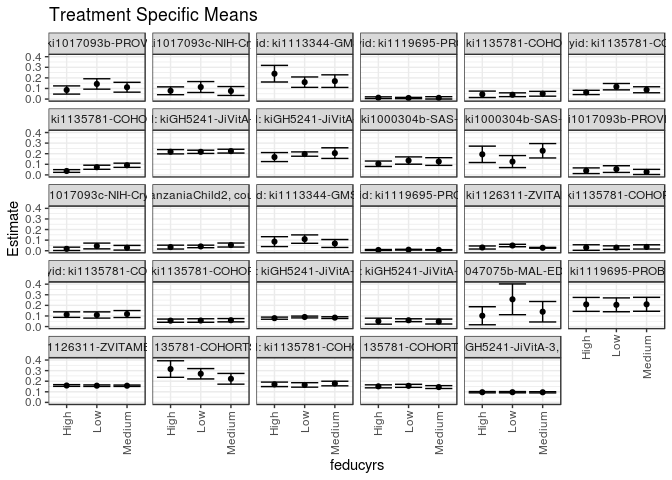

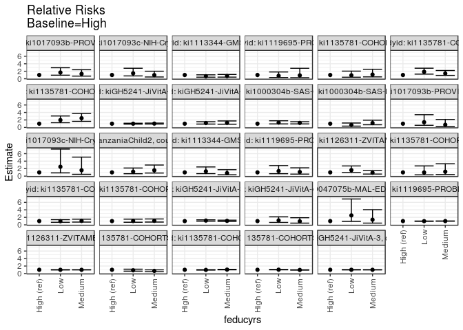

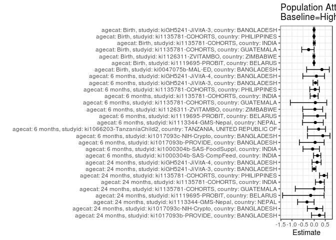

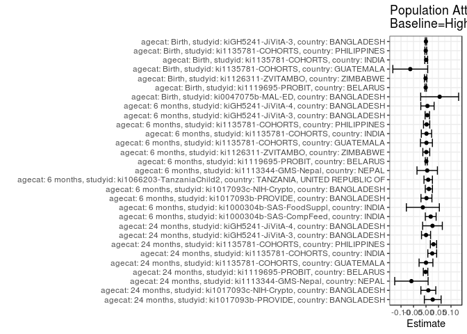

## Results Table

### Parameter: TSM

| agecat | studyid | country | intervention_level | baseline_level | estimate | ci_lower | ci_upper |
| --- | --- | --- | --- | --- | --- | --- | --- |
| Birth | ki0047075b-MAL-ED | BANGLADESH | High | NA | 0.1020408 | 0.0169678 | 0.1871138 |
| Birth | ki0047075b-MAL-ED | BANGLADESH | Low | NA | 0.2571429 | 0.1118044 | 0.4024813 |
| Birth | ki0047075b-MAL-ED | BANGLADESH | Medium | NA | 0.1400000 | 0.0434610 | 0.2365390 |
| Birth | ki1119695-PROBIT | BELARUS | High | NA | 0.2091830 | 0.1434778 | 0.2748881 |
| Birth | ki1119695-PROBIT | BELARUS | Low | NA | 0.2053396 | 0.1399700 | 0.2707091 |
| Birth | ki1119695-PROBIT | BELARUS | Medium | NA | 0.2101306 | 0.1442690 | 0.2759923 |
| Birth | ki1126311-ZVITAMBO | ZIMBABWE | High | NA | 0.1593430 | 0.1513141 | 0.1673718 |
| Birth | ki1126311-ZVITAMBO | ZIMBABWE | Low | NA | 0.1577788 | 0.1506050 | 0.1649526 |
| Birth | ki1126311-ZVITAMBO | ZIMBABWE | Medium | NA | 0.1574202 | 0.1510041 | 0.1638363 |
| Birth | ki1135781-COHORTS | GUATEMALA | High | NA | 0.3150319 | 0.2369195 | 0.3931443 |
| Birth | ki1135781-COHORTS | GUATEMALA | Low | NA | 0.2702442 | 0.2213803 | 0.3191081 |
| Birth | ki1135781-COHORTS | GUATEMALA | Medium | NA | 0.2227572 | 0.1721596 | 0.2733547 |
| Birth | ki1135781-COHORTS | INDIA | High | NA | 0.1703861 | 0.1490089 | 0.1917634 |
| Birth | ki1135781-COHORTS | INDIA | Low | NA | 0.1647166 | 0.1437180 | 0.1857152 |
| Birth | ki1135781-COHORTS | INDIA | Medium | NA | 0.1780523 | 0.1561943 | 0.1999103 |
| Birth | ki1135781-COHORTS | PHILIPPINES | High | NA | 0.1515831 | 0.1375484 | 0.1656178 |
| Birth | ki1135781-COHORTS | PHILIPPINES | Low | NA | 0.1562042 | 0.1420147 | 0.1703936 |
| Birth | ki1135781-COHORTS | PHILIPPINES | Medium | NA | 0.1446937 | 0.1311197 | 0.1582677 |
| Birth | kiGH5241-JiVitA-3 | BANGLADESH | High | NA | 0.0959590 | 0.0900427 | 0.1018753 |
| Birth | kiGH5241-JiVitA-3 | BANGLADESH | Low | NA | 0.0962037 | 0.0905620 | 0.1018454 |
| Birth | kiGH5241-JiVitA-3 | BANGLADESH | Medium | NA | 0.0954026 | 0.0896891 | 0.1011160 |
| 6 months | ki1000304b-SAS-CompFeed | INDIA | High | NA | 0.1051050 | 0.0795050 | 0.1307050 |
| 6 months | ki1000304b-SAS-CompFeed | INDIA | Low | NA | 0.1354392 | 0.1010164 | 0.1698620 |
| 6 months | ki1000304b-SAS-CompFeed | INDIA | Medium | NA | 0.1261749 | 0.0899955 | 0.1623542 |
| 6 months | ki1000304b-SAS-FoodSuppl | INDIA | High | NA | 0.1941757 | 0.1167638 | 0.2715875 |
| 6 months | ki1000304b-SAS-FoodSuppl | INDIA | Low | NA | 0.1256282 | 0.0689447 | 0.1823116 |
| 6 months | ki1000304b-SAS-FoodSuppl | INDIA | Medium | NA | 0.2278528 | 0.1598861 | 0.2958195 |
| 6 months | ki1017093b-PROVIDE | BANGLADESH | High | NA | 0.0394089 | 0.0126209 | 0.0661968 |
| 6 months | ki1017093b-PROVIDE | BANGLADESH | Low | NA | 0.0550000 | 0.0233769 | 0.0866231 |
| 6 months | ki1017093b-PROVIDE | BANGLADESH | Medium | NA | 0.0279330 | 0.0037727 | 0.0520932 |

[output cut: 57 more lines]

### Parameter: E(Y)

| agecat | studyid | country | intervention_level | baseline_level | estimate | ci_lower | ci_upper |
| --- | --- | --- | --- | --- | --- | --- | --- |
| Birth | ki0047075b-MAL-ED | BANGLADESH | NA | NA | 0.1567164 | 0.0949338 | 0.2184990 |
| Birth | ki1119695-PROBIT | BELARUS | NA | NA | 0.2079497 | 0.1424160 | 0.2734834 |
| Birth | ki1126311-ZVITAMBO | ZIMBABWE | NA | NA | 0.1577315 | 0.1513599 | 0.1641031 |
| Birth | ki1135781-COHORTS | GUATEMALA | NA | NA | 0.2520891 | 0.2203065 | 0.2838718 |
| Birth | ki1135781-COHORTS | INDIA | NA | NA | 0.1711851 | 0.1506302 | 0.1917400 |
| Birth | ki1135781-COHORTS | PHILIPPINES | NA | NA | 0.1506598 | 0.1372339 | 0.1640858 |
| Birth | kiGH5241-JiVitA-3 | BANGLADESH | NA | NA | 0.0956568 | 0.0903208 | 0.1009928 |
| 6 months | ki1000304b-SAS-CompFeed | INDIA | NA | NA | 0.1239669 | 0.0988748 | 0.1490591 |
| 6 months | ki1000304b-SAS-FoodSuppl | INDIA | NA | NA | 0.1815789 | 0.1427684 | 0.2203895 |
| 6 months | ki1017093b-PROVIDE | BANGLADESH | NA | NA | 0.0412371 | 0.0250690 | 0.0574052 |
| 6 months | ki1017093c-NIH-Crypto | BANGLADESH | NA | NA | 0.0293706 | 0.0169860 | 0.0417552 |
| 6 months | ki1066203-TanzaniaChild2 | TANZANIA, UNITED REPUBLIC OF | NA | NA | 0.0431334 | 0.0342652 | 0.0520016 |
| 6 months | ki1113344-GMS-Nepal | NEPAL | NA | NA | 0.0907473 | 0.0669775 | 0.1145172 |
| 6 months | ki1119695-PROBIT | BELARUS | NA | NA | 0.0084172 | 0.0066782 | 0.0101561 |
| 6 months | ki1126311-ZVITAMBO | ZIMBABWE | NA | NA | 0.0316235 | 0.0277962 | 0.0354508 |
| 6 months | ki1135781-COHORTS | GUATEMALA | NA | NA | 0.0320442 | 0.0205636 | 0.0435248 |
| 6 months | ki1135781-COHORTS | INDIA | NA | NA | 0.1148014 | 0.0980067 | 0.1315962 |
| 6 months | ki1135781-COHORTS | PHILIPPINES | NA | NA | 0.0581577 | 0.0490934 | 0.0672220 |
| 6 months | kiGH5241-JiVitA-3 | BANGLADESH | NA | NA | 0.0845079 | 0.0795688 | 0.0894470 |
| 6 months | kiGH5241-JiVitA-4 | BANGLADESH | NA | NA | 0.0568099 | 0.0457042 | 0.0679156 |
| 24 months | ki1017093b-PROVIDE | BANGLADESH | NA | NA | 0.1124567 | 0.0866788 | 0.1382347 |
| 24 months | ki1017093c-NIH-Crypto | BANGLADESH | NA | NA | 0.0875486 | 0.0630907 | 0.1120065 |
| 24 months | ki1113344-GMS-Nepal | NEPAL | NA | NA | 0.1810865 | 0.1471967 | 0.2149763 |
| 24 months | ki1119695-PROBIT | BELARUS | NA | NA | 0.0111630 | 0.0050745 | 0.0172515 |
| 24 months | ki1135781-COHORTS | GUATEMALA | NA | NA | 0.0449102 | 0.0320802 | 0.0577401 |
| 24 months | ki1135781-COHORTS | INDIA | NA | NA | 0.0875912 | 0.0726161 | 0.1025664 |
| 24 months | ki1135781-COHORTS | PHILIPPINES | NA | NA | 0.0668392 | 0.0566723 | 0.0770060 |
| 24 months | kiGH5241-JiVitA-3 | BANGLADESH | NA | NA | 0.2187803 | 0.2086815 | 0.2288790 |
| 24 months | kiGH5241-JiVitA-4 | BANGLADESH | NA | NA | 0.1941856 | 0.1762345 | 0.2121367 |

### Parameter: RR

| agecat | studyid | country | intervention_level | baseline_level | estimate | ci_lower | ci_upper |
| --- | --- | --- | --- | --- | --- | --- | --- |
| Birth | ki0047075b-MAL-ED | BANGLADESH | High | High | 1.0000000 | 1.0000000 | 1.0000000 |
| Birth | ki0047075b-MAL-ED | BANGLADESH | Low | High | 2.5200000 | 0.9203657 | 6.8998658 |
| Birth | ki0047075b-MAL-ED | BANGLADESH | Medium | High | 1.3720000 | 0.4650249 | 4.0479210 |
| Birth | ki1119695-PROBIT | BELARUS | High | High | 1.0000000 | 1.0000000 | 1.0000000 |
| Birth | ki1119695-PROBIT | BELARUS | Low | High | 0.9816266 | 0.9581295 | 1.0056999 |
| Birth | ki1119695-PROBIT | BELARUS | Medium | High | 1.0045303 | 0.9895077 | 1.0197811 |
| Birth | ki1126311-ZVITAMBO | ZIMBABWE | High | High | 1.0000000 | 1.0000000 | 1.0000000 |
| Birth | ki1126311-ZVITAMBO | ZIMBABWE | Low | High | 0.9901834 | 0.9528193 | 1.0290128 |
| Birth | ki1126311-ZVITAMBO | ZIMBABWE | Medium | High | 0.9879331 | 0.9560832 | 1.0208440 |
| Birth | ki1135781-COHORTS | GUATEMALA | High | High | 1.0000000 | 1.0000000 | 1.0000000 |
| Birth | ki1135781-COHORTS | GUATEMALA | Low | High | 0.8578313 | 0.6338731 | 1.1609177 |
| Birth | ki1135781-COHORTS | GUATEMALA | Medium | High | 0.7070941 | 0.5072215 | 0.9857271 |
| Birth | ki1135781-COHORTS | INDIA | High | High | 1.0000000 | 1.0000000 | 1.0000000 |
| Birth | ki1135781-COHORTS | INDIA | Low | High | 0.9667254 | 0.9062945 | 1.0311858 |
| Birth | ki1135781-COHORTS | INDIA | Medium | High | 1.0449927 | 0.9803732 | 1.1138715 |
| Birth | ki1135781-COHORTS | PHILIPPINES | High | High | 1.0000000 | 1.0000000 | 1.0000000 |
| Birth | ki1135781-COHORTS | PHILIPPINES | Low | High | 1.0304852 | 0.9852169 | 1.0778336 |
| Birth | ki1135781-COHORTS | PHILIPPINES | Medium | High | 0.9545502 | 0.9143001 | 0.9965723 |
| Birth | kiGH5241-JiVitA-3 | BANGLADESH | High | High | 1.0000000 | 1.0000000 | 1.0000000 |
| Birth | kiGH5241-JiVitA-3 | BANGLADESH | Low | High | 1.0025498 | 0.9640946 | 1.0425389 |
| Birth | kiGH5241-JiVitA-3 | BANGLADESH | Medium | High | 0.9942015 | 0.9559405 | 1.0339939 |
| 6 months | ki1000304b-SAS-CompFeed | INDIA | High | High | 1.0000000 | 1.0000000 | 1.0000000 |
| 6 months | ki1000304b-SAS-CompFeed | INDIA | Low | High | 1.2886086 | 0.9376544 | 1.7709211 |
| 6 months | ki1000304b-SAS-CompFeed | INDIA | Medium | High | 1.2004650 | 0.9443943 | 1.5259686 |
| 6 months | ki1000304b-SAS-FoodSuppl | INDIA | High | High | 1.0000000 | 1.0000000 | 1.0000000 |
| 6 months | ki1000304b-SAS-FoodSuppl | INDIA | Low | High | 0.6469819 | 0.3545041 | 1.1807640 |
| 6 months | ki1000304b-SAS-FoodSuppl | INDIA | Medium | High | 1.1734365 | 0.7133852 | 1.9301679 |
| 6 months | ki1017093b-PROVIDE | BANGLADESH | High | High | 1.0000000 | 1.0000000 | 1.0000000 |
| 6 months | ki1017093b-PROVIDE | BANGLADESH | Low | High | 1.3956250 | 0.5729486 | 3.3995532 |
| 6 months | ki1017093b-PROVIDE | BANGLADESH | Medium | High | 0.7087989 | 0.2359205 | 2.1295134 |

[output cut: 57 more lines]

### Parameter: PAR

| agecat | studyid | country | intervention_level | baseline_level | estimate | ci_lower | ci_upper |
| --- | --- | --- | --- | --- | --- | --- | --- |
| Birth | ki0047075b-MAL-ED | BANGLADESH | High | NA | 0.0546756 | -0.0212288 | 0.1305800 |
| Birth | ki1119695-PROBIT | BELARUS | High | NA | -0.0012333 | -0.0041747 | 0.0017082 |
| Birth | ki1126311-ZVITAMBO | ZIMBABWE | High | NA | -0.0016115 | -0.0064188 | 0.0031957 |
| Birth | ki1135781-COHORTS | GUATEMALA | High | NA | -0.0629427 | -0.1327459 | 0.0068604 |
| Birth | ki1135781-COHORTS | INDIA | High | NA | 0.0007990 | -0.0048991 | 0.0064970 |
| Birth | ki1135781-COHORTS | PHILIPPINES | High | NA | -0.0009233 | -0.0045202 | 0.0026736 |
| Birth | kiGH5241-JiVitA-3 | BANGLADESH | High | NA | -0.0003022 | -0.0030142 | 0.0024097 |
| 6 months | ki1000304b-SAS-CompFeed | INDIA | High | NA | 0.0188620 | -0.0027372 | 0.0404611 |
| 6 months | ki1000304b-SAS-FoodSuppl | INDIA | High | NA | -0.0125967 | -0.0786204 | 0.0534269 |
| 6 months | ki1017093b-PROVIDE | BANGLADESH | High | NA | 0.0018282 | -0.0200444 | 0.0237009 |
| 6 months | ki1017093c-NIH-Crypto | BANGLADESH | High | NA | 0.0114495 | -0.0029263 | 0.0258253 |
| 6 months | ki1066203-TanzaniaChild2 | TANZANIA, UNITED REPUBLIC OF | High | NA | 0.0088289 | -0.0081105 | 0.0257683 |
| 6 months | ki1113344-GMS-Nepal | NEPAL | High | NA | 0.0048062 | -0.0360687 | 0.0456811 |
| 6 months | ki1119695-PROBIT | BELARUS | High | NA | 0.0013070 | -0.0028060 | 0.0054200 |
| 6 months | ki1126311-ZVITAMBO | ZIMBABWE | High | NA | 0.0011257 | -0.0126632 | 0.0149146 |
| 6 months | ki1135781-COHORTS | GUATEMALA | High | NA | 0.0017412 | -0.0220695 | 0.0255519 |
| 6 months | ki1135781-COHORTS | INDIA | High | NA | 0.0018840 | -0.0187467 | 0.0225148 |
| 6 months | ki1135781-COHORTS | PHILIPPINES | High | NA | 0.0024872 | -0.0099576 | 0.0149321 |
| 6 months | kiGH5241-JiVitA-3 | BANGLADESH | High | NA | 0.0051763 | -0.0036854 | 0.0140381 |
| 6 months | kiGH5241-JiVitA-4 | BANGLADESH | High | NA | 0.0058460 | -0.0207381 | 0.0324300 |
| 24 months | ki1017093b-PROVIDE | BANGLADESH | High | NA | 0.0268998 | -0.0066356 | 0.0604351 |
| 24 months | ki1017093c-NIH-Crypto | BANGLADESH | High | NA | 0.0093237 | -0.0204564 | 0.0391038 |
| 24 months | ki1113344-GMS-Nepal | NEPAL | High | NA | -0.0583741 | -0.1251752 | 0.0084271 |
| 24 months | ki1119695-PROBIT | BELARUS | High | NA | -0.0017402 | -0.0108014 | 0.0073210 |
| 24 months | ki1135781-COHORTS | GUATEMALA | High | NA | -0.0000336 | -0.0276458 | 0.0275785 |
| 24 months | ki1135781-COHORTS | INDIA | High | NA | 0.0249635 | 0.0072788 | 0.0426482 |
| 24 months | ki1135781-COHORTS | PHILIPPINES | High | NA | 0.0300376 | 0.0175201 | 0.0425550 |
| 24 months | kiGH5241-JiVitA-3 | BANGLADESH | High | NA | 0.0001827 | -0.0179488 | 0.0183142 |
| 24 months | kiGH5241-JiVitA-4 | BANGLADESH | High | NA | 0.0259122 | -0.0134985 | 0.0653230 |

### Parameter: PAF

| agecat | studyid | country | intervention_level | baseline_level | estimate | ci_lower | ci_upper |
| --- | --- | --- | --- | --- | --- | --- | --- |
| Birth | ki0047075b-MAL-ED | BANGLADESH | High | NA | 0.3488824 | -0.3387079 | 0.6833110 |
| Birth | ki1119695-PROBIT | BELARUS | High | NA | -0.0059306 | -0.0202324 | 0.0081708 |
| Birth | ki1126311-ZVITAMBO | ZIMBABWE | High | NA | -0.0102168 | -0.0411564 | 0.0198033 |
| Birth | ki1135781-COHORTS | GUATEMALA | High | NA | -0.2496845 | -0.5599516 | -0.0011280 |
| Birth | ki1135781-COHORTS | INDIA | High | NA | 0.0046674 | -0.0291912 | 0.0374120 |
| Birth | ki1135781-COHORTS | PHILIPPINES | High | NA | -0.0061284 | -0.0302726 | 0.0174500 |
| Birth | kiGH5241-JiVitA-3 | BANGLADESH | High | NA | -0.0031596 | -0.0319208 | 0.0248000 |
| 6 months | ki1000304b-SAS-CompFeed | INDIA | High | NA | 0.1521531 | -0.0289507 | 0.3013812 |
| 6 months | ki1000304b-SAS-FoodSuppl | INDIA | High | NA | -0.0693732 | -0.5023513 | 0.2388204 |
| 6 months | ki1017093b-PROVIDE | BANGLADESH | High | NA | 0.0443350 | -0.6642877 | 0.4512393 |
| 6 months | ki1017093c-NIH-Crypto | BANGLADESH | High | NA | 0.3898276 | -0.3012672 | 0.7138863 |
| 6 months | ki1066203-TanzaniaChild2 | TANZANIA, UNITED REPUBLIC OF | High | NA | 0.2046887 | -0.2993961 | 0.5132200 |
| 6 months | ki1113344-GMS-Nepal | NEPAL | High | NA | 0.0529623 | -0.5234671 | 0.4112899 |
| 6 months | ki1119695-PROBIT | BELARUS | High | NA | 0.1552815 | -0.4981092 | 0.5237001 |
| 6 months | ki1126311-ZVITAMBO | ZIMBABWE | High | NA | 0.0355974 | -0.5156705 | 0.3863625 |
| 6 months | ki1135781-COHORTS | GUATEMALA | High | NA | 0.0543365 | -1.0743176 | 0.5688801 |
| 6 months | ki1135781-COHORTS | INDIA | High | NA | 0.0164113 | -0.1806864 | 0.1806066 |
| 6 months | ki1135781-COHORTS | PHILIPPINES | High | NA | 0.0427671 | -0.1968548 | 0.2344143 |
| 6 months | kiGH5241-JiVitA-3 | BANGLADESH | High | NA | 0.0612523 | -0.0498107 | 0.1605655 |
| 6 months | kiGH5241-JiVitA-4 | BANGLADESH | High | NA | 0.1029037 | -0.5099405 | 0.4670110 |
| 24 months | ki1017093b-PROVIDE | BANGLADESH | High | NA | 0.2392010 | -0.1195143 | 0.4829765 |
| 24 months | ki1017093c-NIH-Crypto | BANGLADESH | High | NA | 0.1064969 | -0.3059365 | 0.3886780 |
| 24 months | ki1113344-GMS-Nepal | NEPAL | High | NA | -0.3223545 | -0.7450238 | -0.0020616 |
| 24 months | ki1119695-PROBIT | BELARUS | High | NA | -0.1558890 | -1.4211257 | 0.4481578 |
| 24 months | ki1135781-COHORTS | GUATEMALA | High | NA | -0.0007491 | -0.8498780 | 0.4586137 |
| 24 months | ki1135781-COHORTS | INDIA | High | NA | 0.2850004 | 0.0599180 | 0.4561917 |
| 24 months | ki1135781-COHORTS | PHILIPPINES | High | NA | 0.4494006 | 0.2434235 | 0.5993006 |
| 24 months | kiGH5241-JiVitA-3 | BANGLADESH | High | NA | 0.0008352 | -0.0855729 | 0.0803654 |
| 24 months | kiGH5241-JiVitA-4 | BANGLADESH | High | NA | 0.1334406 | -0.0948637 | 0.3141382 |